# Project plan & Initial Data Analysis (IDA)

STAT5003 group project 18

# 1 Overview of the problem

Credit scores are important indicators of an individual’s credit risk and are often used by banks and financial institutions to determine the approval of loans, credit card applications or the setting of loan interest rates. Therefore, this project focuses on predicting an individual’s credit score by developing machine learning models. In this context, we will take individual’s credit information such as age, occupation, income as independent variables, and credit scores such as “good,” “standard,” and “poor” as dependent variables. Based on this understanding, the problem can be abstracted as a three-class problem. Our model aims to ascertain the specific category each individual falls into based on their input characteristics.

By automating the classification of credit scores, on the one hand, financial institutions can reduce labor costs to improve the efficiency and accuracy of decision-making, on the other hand, it can also help them discover potential credit risk patterns and provide insights for financial risk management strategies. Therefore, by utilizing machine learning technology to classify credit scores, we can improve the efficiency of financial services while providing customers with more personalized and accurate services.

# 2 Dataset description and preprocessing

The dataset comes from kaggle (https://www.kaggle.com/datasets/parisrohan/credit-score-classification?resource=download&select=test.csv) and consists of 100,000 rows and 28 columns.There are 19 numeric attributes (Monthly_Inhand_Salary, Num_Bank_Accounts, Num_Credit_Card, Interest_Rate, Delay_from_due_date, Num_Credit_Inquiries,Credit_Utilization_Ratio, Total_EMI_per_month, Annual_Income, Age, Num_of_Loan, Num_of_Delayed_Payment, Changed_Credit_Limit, Num_of_Loan, Outstanding_Debt, Monthly_Balance, Credit_History_Age, Payment_of_Min_Amount, Amount_invested_monthly) and 9 categorical attributes (Customer_ID, Month, Name, SSN, Occupation, Type_of_Loan, Credit_Mix, Payment_Behaviour, Credit_Score). After preliminary exploration, we found that the dataset contains a large number of missing values and outliers. In addition, there are a lot of special characters and invalid fields in the data. Therefore, we need to explore more deeply and determine the best strategy for data cleansing.

```r
library(tidyverse)
library(ggplot2)
library(dplyr)
library(reshape2)
library(gridExtra)
library(caret)
library(glmnet)
library(randomForest)
library(modeltools)
library(stats4)
library(knitr)
credit.data <- read_csv('train.csv',show_col_types = FALSE)
```

We analyzed the data set and found that there were missing values in the data set, so we visualized the proportion of missing values for each variable:

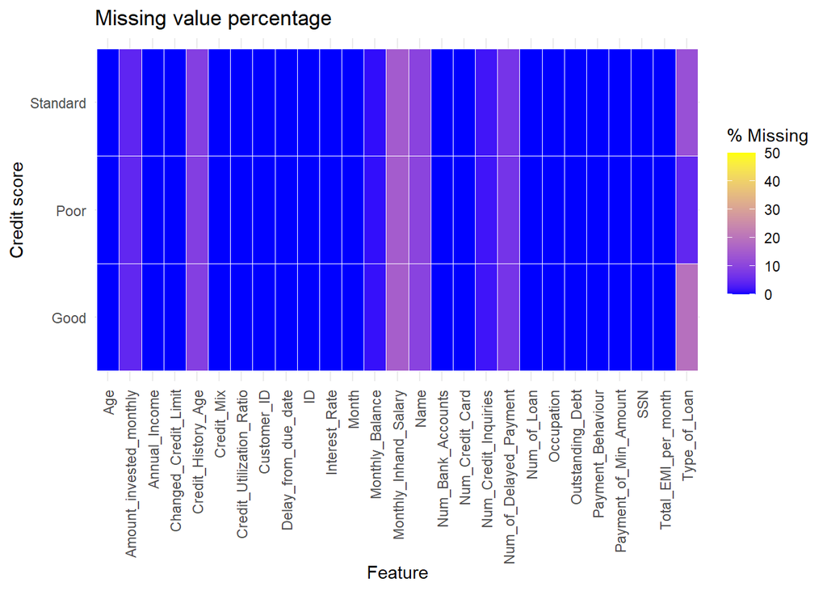

```r
missing_data <- credit.data %>%
  group_by(Credit_Score) %>%
  summarise(across(everything(), ~ sum(is.na(.)) / n() * 100)) %>%
  pivot_longer(cols = -Credit_Score, names_to = "Feature", values_to = "Percentageofmissingvalue")

ggplot(missing_data, aes(x=Feature, y=Credit_Score, fill=Percentageofmissingvalue)) +
  geom_tile(color = "white") +
  scale_fill_gradient(low="blue", high="yellow", limits=c(0,50)) +
  theme_minimal() +
  theme(axis.text.x = element_text(angle=90, vjust=0.5, hjust=1)) +
  labs(title="Missing value percentage", x="Feature", y="Credit score", fill="% Missing")
```

Based on the above visualization, we found that the proportion of missing values in the data set is not very high, so we delete rows with missing values in the subsequent data cleaning. After analysis, we found that some features have no impact on our final classification results(such as ID, etc.), so we delete these columns:

```r
remove.unnece.data <- credit.data %>%
  select(-c('ID', 'Customer_ID', 'Month', 'Name', 'SSN', 'Credit_History_Age','Monthly_Inhand_Salary', 'Type_of_Loan'))
```

In the dataset, we can see that some columns should be numeric, but they have string values (like _, !@9#%8, etc.) which don’t make sense, so we convert these strings to NA. Due to the large size of the data set, deleting some data rows has little impact on the accuracy of the classification task, so we delete all data rows with missing values.

```r
remove.char.data <- remove.unnece.data %>%
  mutate_if(is.character, function(x) gsub("______", NA, x)) %>%
  mutate_if(is.character, function(x) gsub("!@9#%8", NA, x)) %>%
  mutate_if(is.character, function(x) ifelse(x == "_", NA_character_, x)) %>%
  mutate_if(is.character, function(x) ifelse(x == "NM", NA_character_, x)) %>%
  drop_na
```

After deleting all missing values, we can see that some columns have specific string values (such as -$, etc.). So we deal with these values.

```r
remove.str.data <- remove.char.data %>%
  mutate_if(is.character, function(x) gsub("_$", "", x)) %>%
  mutate_if(is.character, function(x) gsub("^_*|_*$", "", x))
```

In addition, we found that some numerical data has negative numbers, so we first find the columns with negative data.

```r
#neg_values <- colSums(remove.str.data < 0)
#neg_features <- names(neg_values)[neg_values > 0]
#neg_features
```

```r
#remove.neg_data <- remove.str.data %>%
 # filter(Age >= 0 & Num_Bank_Accounts >= 0 & Num_of_Loan >= 0)
```

After completing the data cleaning, we found that there were errors in the data types of some features, so we adjusted the data types of the relevant features to ensure that they were correct.

```r
data.cleaned <- remove.str.data %>%
  mutate(across(c(Age, Annual_Income,Num_of_Loan,Num_of_Delayed_Payment,Changed_Credit_Limit,Outstanding_Debt,Amount_invested_monthly ,), as.numeric))
# vapply(data.cleaned,class,character(1))
```

```r
detect_and_replace_outliers <- function(x) {
  Q1 <- quantile(x, 0.25, na.rm = TRUE)
  Q3 <- quantile(x, 0.75, na.rm = TRUE)
  IQR <- Q3 - Q1
  lower_bound <- Q1 - 1.5 * IQR
  upper_bound <- Q3 + 1.5 * IQR
  x[x < lower_bound | x > upper_bound] <- NA
  return(x)
}

data.cleaned <- data.cleaned %>%
  mutate(across(where(is.numeric), detect_and_replace_outliers))

data.cleaned <- data.cleaned %>%
  mutate(across(where(is.numeric), ~ifelse(is.na(.), median(., na.rm = TRUE), .)))
```

After drawing the box plot again, we can see that all the numerical attributes are within a reasonable range.

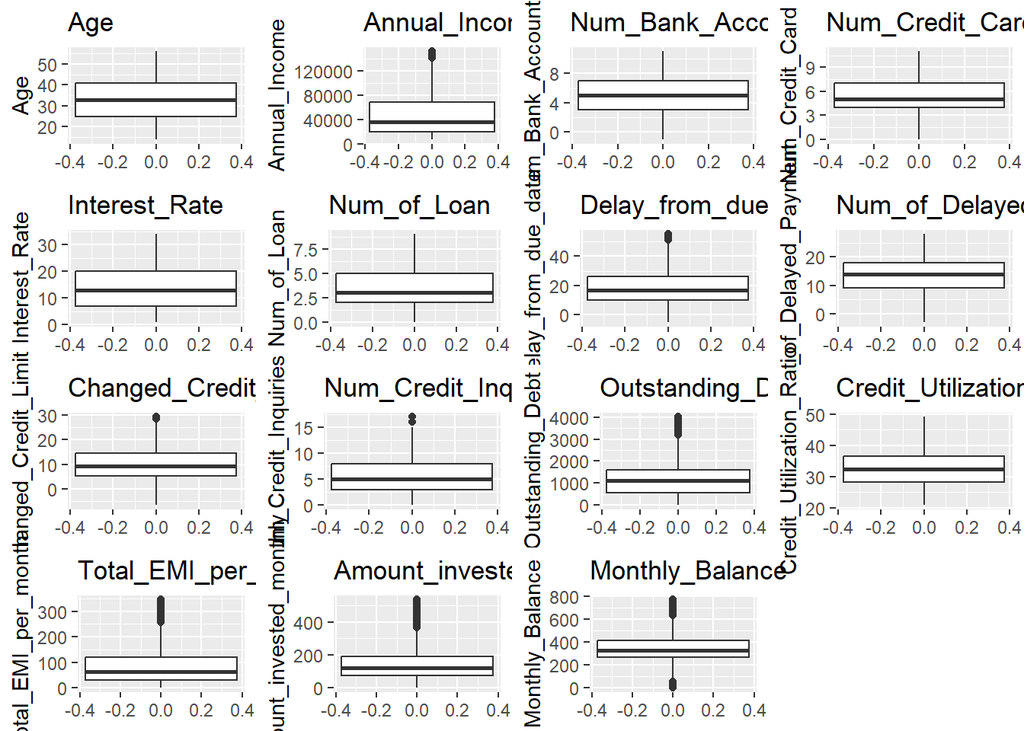

```r
boxplot_list <- lapply(names(data.cleaned)[sapply(data.cleaned, is.numeric)], function(var_name) {
  ggplot(data.cleaned, aes_string(y = var_name)) +
    geom_boxplot() +
    ggtitle(paste(var_name))
})
do.call(grid.arrange, boxplot_list)
```

# 3 Visualization & IDA

## 3.1 Data hot encoding

```r
data.ida <- data.cleaned
```

```r
data.ida$Credit_Score <- NULL

non_numeric_cols <- sapply(data.ida, function(x) !is.numeric(x))
replaced_cols <- data.frame(matrix(ncol = sum(non_numeric_cols), nrow = nrow(data.ida)))
colnames(replaced_cols) <- names(data.ida)[non_numeric_cols]

for (col in names(data.ida)[non_numeric_cols]) {
  unique_values <- unique(data.ida[[col]])
  for (i in seq_along(unique_values)) {
    replaced_cols[data.ida[[col]] == unique_values[i], col] <- i
  }
}

data.ida <- cbind(data.ida[, !non_numeric_cols], replaced_cols)
```

## 3.2 Correlation Exploration

We then used linear correlation to identify correlations in the dataset.

1. Calculate the correlation matrix and set the correlation threshold: Use `cor()` function to calculate correlation coefficient between all features in the dataset and generate a correlation matrix correlation_matrix. set the threshold threshold to 0.7 to focus only on highly correlated pairs of features with correlation coefficient greater than 0.7.
2. Extract the correlation coefficient of upper triangular part: Extract the upper triangular part of the correlation matrix by `upper.tri()` function, which can avoid double checking the correlation of feature pairs.
3. Identify high correlation feature pairs: Use `which()` function to find the index position of the feature pairs whose correlation coefficient is greater than threshold threshold and store it in `high_correlation_indices`.
4. Output high correlation feature pair information: If there are feature pairs with correlation greater than threshold, output the name and correlation coefficient of each pair; if not, output the corresponding message.

```r
correlation_matrix <- cor(data.ida)

threshold <- 0.7

upper_triangle <- correlation_matrix[upper.tri(correlation_matrix)]

high_correlation_indices <- which(upper_triangle > threshold)

if (length(high_correlation_indices) > 0) {
  print("Highly correlated feature pairs:")
  for (i in high_correlation_indices) {
    row_index <- (i - 1) %/% nrow(correlation_matrix) + 1
    col_index <- (i - 1) %% nrow(correlation_matrix) + 1
    print(paste0(names(data.ida)[row_index], " - ", names(data.ida)[col_index], ": ", upper_triangle[i]))
  }
} else {
  print("No highly correlated feature pairs found above the threshold.")
}
```

```
## [1] "Highly correlated feature pairs:"
## [1] "Delay_from_due_date - Changed_Credit_Limit: 0.719560849816391"
## [1] "Delay_from_due_date - Outstanding_Debt: 0.744084438133157"
## [1] "Delay_from_due_date - Amount_invested_monthly: 0.751616306734694"
## [1] "Changed_Credit_Limit - Age: 0.769494417033794"
```

With the output of the last chunk we can get a high correlation between `Delay_from_due_date` and `Changed_Credit_Limit`, `Outstanding_Debt`, `Amount_invested_monthly`, `Changed_Credit_Limit` and `Age` are also highly correlated.

```r
data.ida <- subset(data.ida, select = -c(Num_Credit_Inquiries, Total_EMI_per_month, Credit_Mix, Num_of_Delayed_Payment))
```

## 3.3 Explore significant variables

Then we apply principal component analysis (PCA) to the processed data and merge the PCA results (`pca_data`) with the `Credit_Score` column from the original dataset (`data.cleaned`), creating a new dataset named `pca_with_label`. This allows each sample to be associated with coordinates in the principal component space along with its corresponding credit score (`Credit_Score`).

```r
pca_result <- prcomp(data.ida, scale. = TRUE)

pca_data <- as.data.frame(pca_result$x)

pca_with_label <- cbind(pca_data, Credit_Score = data.cleaned$Credit_Score)
```

We identify and prioritize the key original features that drive the variation captured by the first principal component in the dataset analyzed using PCA.

1. Rotation Matrix Extraction: The `rotation_matrix <- pca_result$rotation` line extracts the rotation matrix, which indicates how original features contribute to each principal component.
2. Coefficients of PC1: `first_pc_coefficients <- rotation_matrix[, 1]` retrieves the coefficients of the first principal component (PC1). These coefficients represent the contributions of each original feature to PC1.
3. Absolute Coefficients: `abs_coefficients <- abs(first_pc_coefficients)` calculates the absolute values of the PC1 coefficients to assess the magnitude of each feature’s influence.
4. Sorting Coefficients: `sorted_coefficients <- sort(abs_coefficients, decreasing = TRUE)` sorts the absolute coefficients in descending order, revealing the most influential features for PC1.

```r
rotation_matrix <- pca_result$rotation

first_pc_coefficients <- rotation_matrix[, 1]

abs_coefficients <- abs(first_pc_coefficients)

sorted_coefficients <- sort(abs_coefficients, decreasing = TRUE)
```

We have created a heatmap to visualize the importance and contribution of each original feature to the first principal component (PC1). Each tile in the heatmap represents a feature, with tile color intensity indicating the magnitude of the feature’s coefficient for PC1—the darker the color, the greater the contribution. Features are reordered based on the absolute value of their coefficients for PC1, highlighting the impact of each feature in the data dimension reduction process of principal component analysis (PCA).

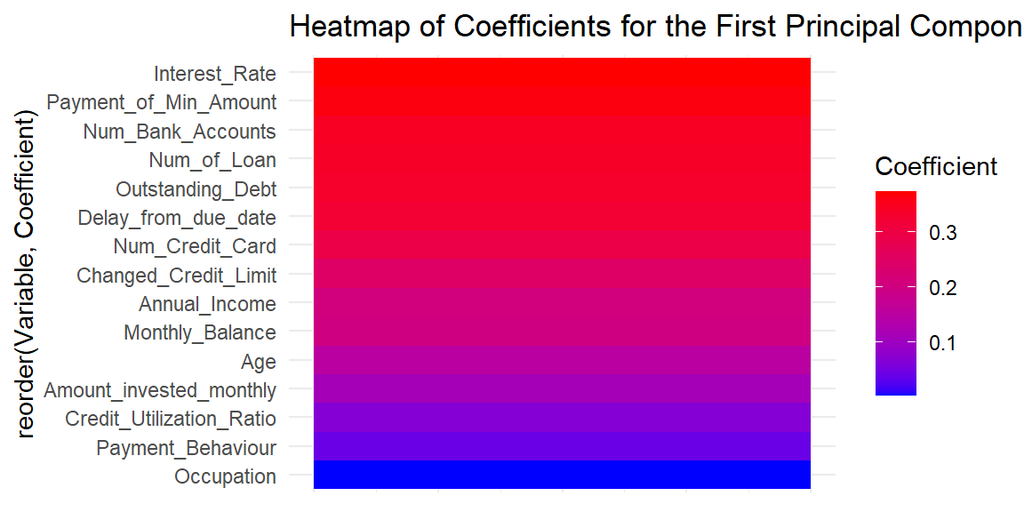

```r
coefficients_df <- data.frame(Variable = names(sorted_coefficients), Coefficient = sorted_coefficients)

library(ggplot2)
ggplot(data = coefficients_df, aes(x = 1, y = reorder(Variable, Coefficient), fill = Coefficient)) +
  geom_tile() +
  scale_fill_gradient(low = "blue", high = "red") +
  theme_minimal() +
  theme(axis.text.x = element_blank(), axis.title.x = element_blank()) +
  labs(title = "Heatmap of Coefficients for the First Principal Component")
```

```r
top_ten_significant_variables <- names(first_pc_coefficients)[head(order(sorted_coefficients, decreasing = TRUE), 8)]

#cat("Significant variables influencing the first principal component:\n")
top_ten_significant_variables
```

```
## [1] "Age"                  "Annual_Income"        "Num_Bank_Accounts"
## [4] "Num_Credit_Card"      "Interest_Rate"        "Num_of_Loan"
## [7] "Delay_from_due_date"  "Changed_Credit_Limit"
```

## 3.4 Significant variable data

```r
set.seed(123)

test_size <- ceiling(0.1 * nrow(data.ida))

index <- sample(seq_len(nrow(data.ida)), size = test_size, replace = FALSE)
data.eva <- data.ida[index, ]
data.cor <- data.eva[, top_ten_significant_variables]
eva_labels <- data.cleaned$Credit_Score[index]
```

This code segment performs Principal Component Analysis (PCA) on a dataset to reduce the dimensionality of the feature space and visualize the data in the principal component space.

**=PCA Analysis and Visualization for Selected Feature Dataset** - Similarly employs the `prcomp()` function to conduct PCA on the selected feature dataset `data.cor`, achieving dimensionality reduction and feature analysis. - Converts the PCA results into a dataframe format and merges them with the credit score labels from the evaluation dataset for visualization and analysis. - Uses `ggplot2` to generate a scatter plot illustrating the distribution of the selected feature dataset in the principal component space. Different credit score categories are differentiated by color.

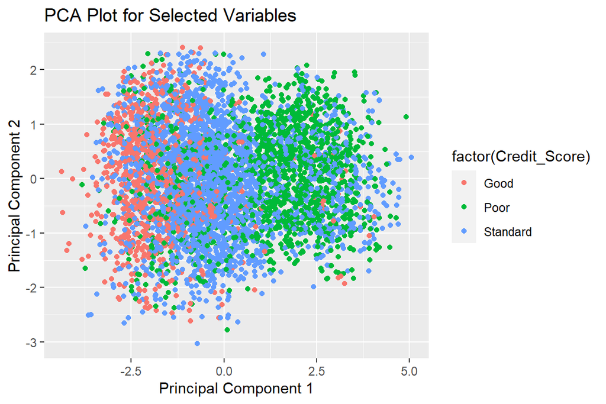

```r
pca_result_cor <- prcomp(data.cor, scale. = TRUE)
pca_data_cor <- as.data.frame(pca_result_cor$x)
pca_with_label_cor <- cbind(pca_data_cor, Credit_Score = eva_labels)

ggplot(data = pca_with_label_cor, aes(x = PC1, y = PC2, color = factor(Credit_Score))) +
  geom_point() +
  labs(x = "Principal Component 1", y = "Principal Component 2", title = "PCA Plot for Selected Variables")
```

## 3.5 Significant variable density plot

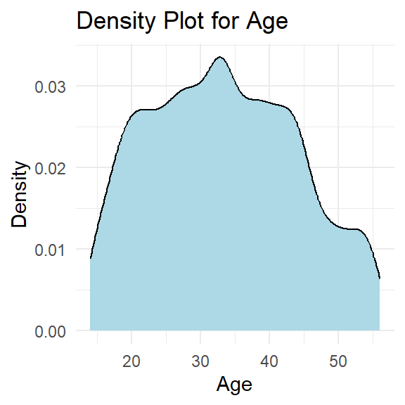

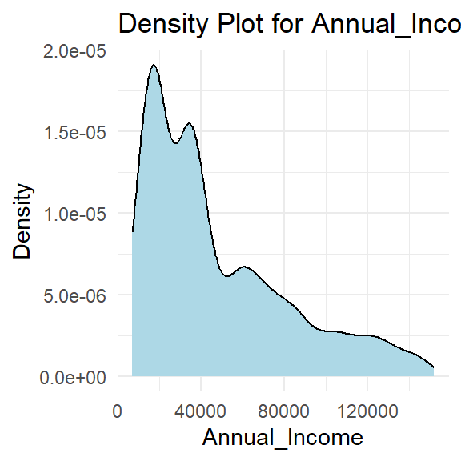

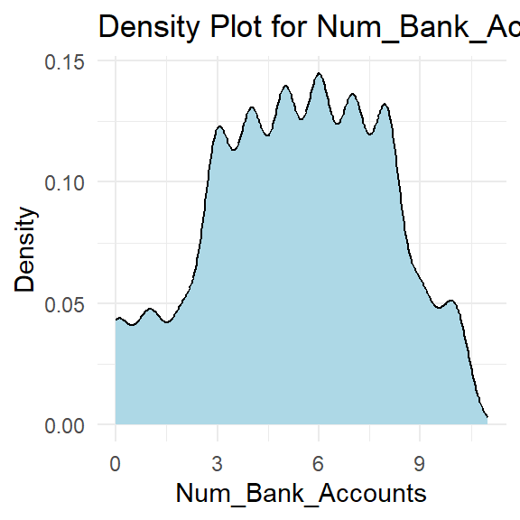

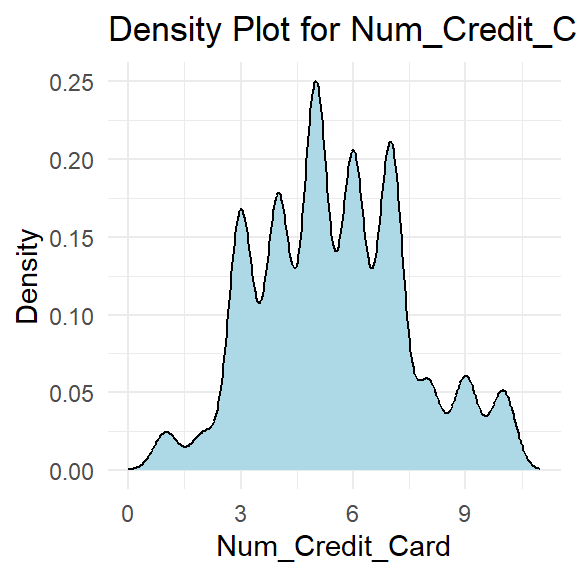

```r
data.den <- data.cor[, 1:4]
plot_density <- function(var_name) {
  ggplot(data.frame(values = data.den[[var_name]]), aes(x = values, y = after_stat(density))) +
    geom_density(fill = "lightblue", color = "black") +
    theme_minimal() +
    labs(title = paste("Density Plot for", var_name),
         x = var_name, y = "Density")
}

for (var_name in names(data.den)) {
  print(plot_density(var_name))
}
```

# 4 Classification algorithms used

In terms of model usage, we chose K-Nearest Neighbors (KNN), logistic regression, Random forest and linear discriminant analysis(LDA) to complete our classification tasks. First, we divide the data set into 80% training set and 20% test set, and set the same and complete factor level for the Credit_Score column of both to better maintain consistency in model training.

```r
set.seed(1234)

inTrain <- createDataPartition(data.cleaned$Credit_Score, p = .8)[[1]]
train_data <- data.cleaned[inTrain, ]
test_data <- data.cleaned[-inTrain, ]

train_data$Credit_Score <- factor(train_data$Credit_Score)
test_data$Credit_Score <- factor(test_data$Credit_Score, levels = levels(train_data$Credit_Score))
```

Here are the models we used in this classification task:

1.K-Nearest Neighbors (KNN):

KNN is a simple and intuitive method which is non-parametric but it can be surprisingly effective. It classified the a new instance based on the majority class of its k-nearest neighbors in the feature space.

As KNN classifies the data by the similarity of instances, it can be particularly effective if the instances of the data have clear local pattern area. For the dataset above, we can apply KNN to cluster those individuals who have similar financial behaviors and assign those individuals into a certain category.

```r
data_with_labels <- data.cleaned %>%
  mutate(Occupation = as.integer(as.factor(Occupation)))

target_sample_size <- floor(nrow(data_with_labels) * 0.1)

set.seed(1234)
inTrain_small <- createDataPartition(data_with_labels$Credit_Score, p = .8)[[1]]
dtrain_data <- data_with_labels[inTrain_small, ]
dtest_data <- data_with_labels[-inTrain_small, ]
```

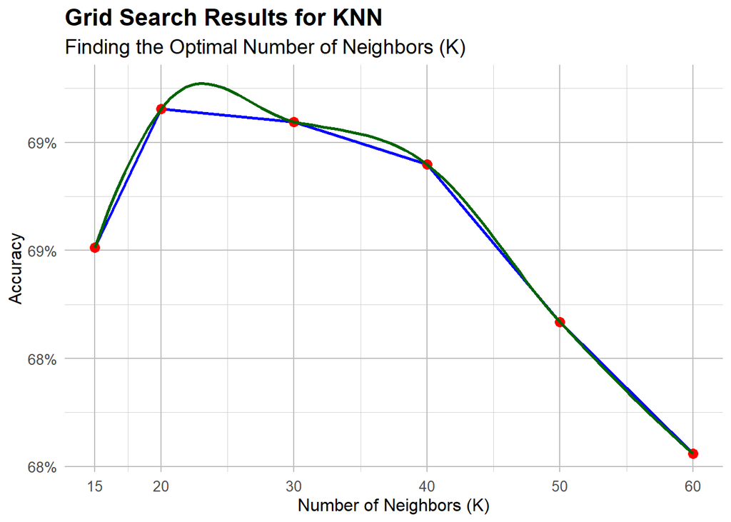

```r
k_range <- c(15,20,30,40,50,60)

set.seed(1234)
knn_model <- train(
  Credit_Score ~ .,
  data = data_with_labels,
  method = "knn",
  trControl = trainControl(method = "cv"),
  tuneGrid = expand.grid(k = k_range),
  preProcess = c("center", "scale")
)

best_k <- knn_model$bestTune$k
results <- knn_model$results

ggplot(results, aes(x = k, y = Accuracy)) +
  geom_line(color = "blue", size = 1) +
  geom_point(color = "red", size = 3) +
  geom_smooth(method = "loess", se = FALSE, color = "darkgreen") +
  labs(
    title = "Grid Search Results for KNN",
    subtitle = "Finding the Optimal Number of Neighbors (K)",
    x = "Number of Neighbors (K)",
    y = "Accuracy",
  ) +
  theme_minimal() +
  theme(
    plot.title = element_text(size = 16, face = "bold"),
    plot.subtitle = element_text(size = 14),
    plot.caption = element_text(size = 10),
    axis.title.x = element_text(size = 12),
    axis.title.y = element_text(size = 12),
    axis.text = element_text(size = 10),
    panel.grid.major = element_line(color = "grey", size = 0.5),
    panel.grid.minor = element_line(color = "lightgrey", size = 0.25)
  ) +
  scale_x_continuous(breaks = k_range) +
  scale_y_continuous(labels = scales::percent_format(accuracy = 1))
```

```r
predictions_knn <- predict(knn_model, newdata = dtest_data)

conf_matrix_knn <- confusionMatrix(predictions_knn, as.factor(dtest_data$Credit_Score))
accuracy_knn <- conf_matrix_knn$overall['Accuracy']
precision_knn <- conf_matrix_knn$byClass[, "Precision"]
recall_knn <- conf_matrix_knn$byClass[, 'Recall']
F1_knn <- conf_matrix_knn$byClass[, 'F1']
```

```r
results <- data.frame(
  Class = c("Good", "Poor", "Standard"),
  Precision= c(precision_knn[1], precision_knn[2], precision_knn[3]),
  Recall = c(recall_knn[1], recall_knn[2], recall_knn[3]),
  F1_Score = c(F1_knn[1], F1_knn[2], F1_knn[3]),
  Accuracy = c(accuracy_knn,accuracy_knn,accuracy_knn)
)
print(paste("Best k value:", best_k))
```

```
## [1] "Best k value: 20"
```

```r
print(results)
```

```
##                    Class Precision    Recall  F1_Score  Accuracy
## Class: Good         Good 0.5866029 0.6868347 0.6327742 0.7199724
## Class: Poor         Poor 0.7369668 0.6349098 0.6821422 0.7199724
## Class: Standard Standard 0.7626199 0.7769585 0.7697224 0.7199724
```

2.Logistic Regression:

Logistic regression is a robust and common model for multiple classification problems. It works well when the relationship between the independent variables and the dependent variable is approximately linear. This dataset include various continuous variables, such as income, balance, and credit utilization ratio, which may have a linear relationship with credit score categories. Logistic regression has strong interpretability with the model coefficients.

Financial institutions can analyze the model coefficients to understand which features have a greater impact on credit rating categories. In addition, outliers have little impact in the logistic regression model, thus this can keep robust in handling complex financial data.

In the model building process, we use grid search to tune the hyperparameters to set the regularization type and intensity. At the same time, 10 fold cross-validation is implemented to ensure that the optimal model configuration can be effectively selected. The result is shown in the figure:

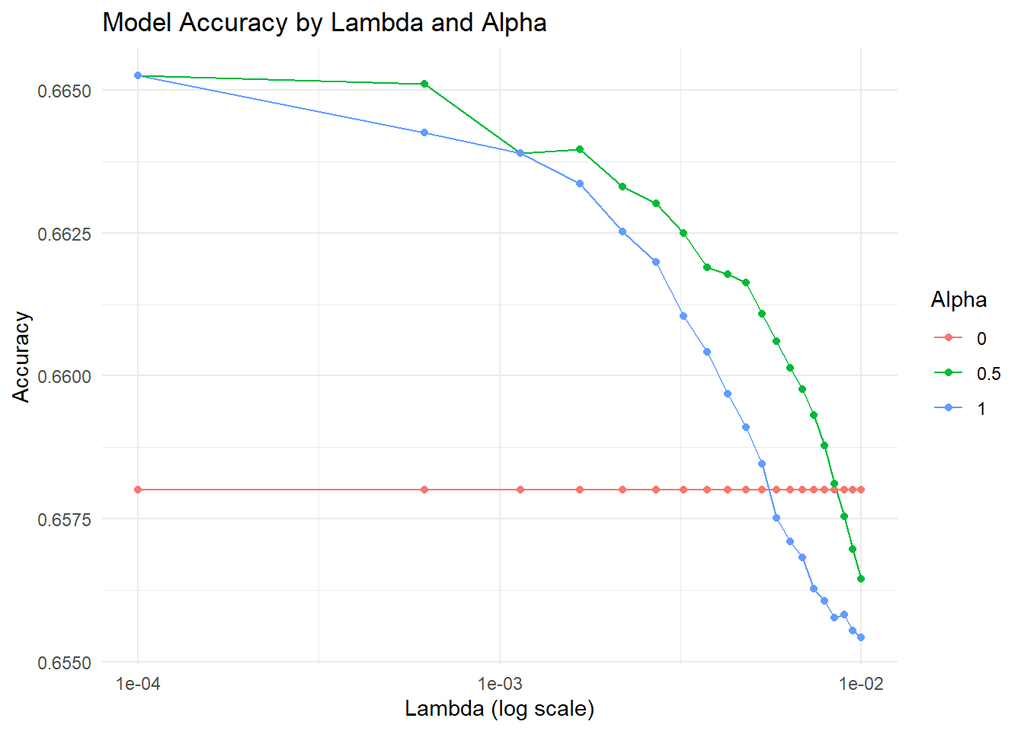

```r
grid <- expand.grid(
  alpha = c(0, 0.5, 1),
  lambda = seq(0.0001, 0.01, length = 20)
)

train_control <- trainControl(
  method = "cv",
  number = 10,
  savePredictions = "final",
  classProbs = TRUE
)

set.seed(123)
model <- train(
  Credit_Score ~ .,
  data = data.cleaned,
  method = "glmnet",
  trControl = train_control,
  tuneGrid = grid
)
results <- model$results

ggplot(data = results, aes(x = lambda, y = Accuracy, group = as.factor(alpha), color = as.factor(alpha))) +
  geom_line() +
  geom_point() +
  scale_x_log10() +
  labs(title = "Model Accuracy by Lambda and Alpha",
       x = "Lambda (log scale)",
       y = "Accuracy",
       color = "Alpha") +
  theme_minimal()
```

```r
print(model$bestTune)
```

```
##    alpha lambda
## 21   0.5  1e-04
```

Therefore, the model is optimal when Elastic Net regularization is adopted and the regularization intensity is 0.0001. The evaluation metrics of the model are as follows:

```r
x_train <- model.matrix(Credit_Score ~ .-1, data = train_data)
y_train <- train_data$Credit_Score

final_model <- glmnet(x_train, y_train, family = "multinomial", alpha = 0.5, lambda = 0.0001)

x_test <- model.matrix(Credit_Score ~ .-1, data = test_data)
predictions <- predict(final_model, s = 0.0001, newx = x_test, type = "class")

predictions <- factor(predictions, levels = levels(test_data$Credit_Score))

conf_matrix <- confusionMatrix(as.factor(predictions), test_data$Credit_Score)

print(conf_matrix$table)
```

```
##           Reference
## Prediction Good Poor Standard
##   Good     1235  269      692
##   Poor       33 1607      733
##   Standard  517 1063     4000
```

```r
accuracy_lr <- conf_matrix$overall['Accuracy']
precision_lr <- conf_matrix$byClass[, "Precision"]
recall_lr <- conf_matrix$byClass[, 'Recall']
F1_lr <- conf_matrix$byClass[, 'F1']

metrics_df <- data.frame(
  Class = rownames(conf_matrix$byClass),
  Precision = precision_lr,
  Recall = recall_lr,
  F1_Score = F1_lr
)

kable(metrics_df, format = "markdown", col.names = c("Class", "Precision", "Recall", "F1 Score"))
```

|  | Class | Precision | Recall | F1 Score |
| --- | --- | --- | --- | --- |
| Class: Good | Class: Good | 0.5623862 | 0.6918768 | 0.6204471 |
| Class: Poor | Class: Poor | 0.6772019 | 0.5467846 | 0.6050452 |
| Class: Standard | Class: Standard | 0.7168459 | 0.7373272 | 0.7269423 |

```r
cat("Accuracy:", accuracy_lr, "\n")
```

```
## Accuracy: 0.6741551
```

3.Random Forest:

Random forest is an ensemble learning method. It combines the prediction results of multiple decision trees to generate robust model. Random forest is useful in this high-dimensional credit dataset that has a mix of numerical and categorical feature. Random forest can avoid overfit data in the training process because it consist many decision trees.

When dealing with high-dimensional credit datasets, Random Forest Ridge can effectively handle complex data containing numerical and categorical features. Meanwhile, models trained on different samples and features have good generalisability and can make better predictions for complex datasets.

```r
rf_model <- randomForest(Credit_Score ~ ., data = train_data, ntree = 100)

predictions <- predict(rf_model, newdata = test_data)

confusion_matrix <- confusionMatrix(predictions, test_data$Credit_Score)
```

```r
precision <- confusion_matrix$byClass[, "Precision"]
recall <- confusion_matrix$byClass[, "Recall"]
f1_score <- confusion_matrix$byClass[, "F1"]
accuracy <- confusion_matrix$overall["Accuracy"]

results <- data.frame(
  Class = c("Good", "Poor", "Standard"),
  Precision = c(precision[1], precision[2], precision[3]),
  Recall = c(recall[1], recall[2], recall[3]),
  F1_Score = c(f1_score[1], f1_score[2], f1_score[3]),
  Accuracy = c(accuracy,accuracy,accuracy)
)

precision_rf <- precision
recall_rf <- recall
f1_score_rf <- f1_score
accuracy_rf <- accuracy


print(results)
```

```
##                    Class Precision    Recall  F1_Score  Accuracy
## Class: Good         Good 0.7262104 0.7310924 0.7286432 0.7870726
## Class: Poor         Poor 0.7782623 0.7893841 0.7837838 0.7870726
## Class: Standard Standard 0.8123255 0.8042396 0.8082623 0.7870726
```

4. linear discriminant analysis(LDA)

The main idea of linear discriminant analysis is to project the data into a new space, and after projection, it is necessary to ensure that the intra-class variance of each category is small and the mean difference between categories is large, so that the data of different categories are as separated as possible in the new space. Through this method, LDA can effectively separate multi-category data, allowing the classifier to classify new data more accurately.

Financial data sets usually contain highly correlated features, and LDA can make good use of these correlations to identify feature combinations that are closely related to credit scores, thereby better distinguishing different categories.

The following is an implementation of LDA classification model:

```r
lda.model <- train(Credit_Score ~ . , data = train_data, method = "lda",
                   trControl = trainControl(method = "repeatedcv", repeats = 5))
lda.pred <- predict(lda.model, test_data)
lad_conf_matrix <- confusionMatrix(lda.pred, test_data$Credit_Score)
cat("LDA confusion matrix: \n")
```

```
## LDA confusion matrix:
```

```r
print(lad_conf_matrix$table)
```

```
##           Reference
## Prediction Good Poor Standard
##   Good     1512  507     1029
##   Poor       20 1680      808
##   Standard  253  752     3588
```

```r
lda_accuracy <- lad_conf_matrix$overall["Accuracy"]
lda_precision <- lad_conf_matrix$byClass[, "Precision"]
lda_recall <- lad_conf_matrix$byClass[, "Recall"]
lda_f1_score <- lad_conf_matrix$byClass[, "F1"]

lda.data.frame <- data.frame(
  Metric = c("Accuracy", "Precision", "Recall", "F1 Score"),
  Good = round(c(lda_accuracy, lad_conf_matrix$byClass["Class: Good", "Precision"], lad_conf_matrix$byClass["Class: Good", "Recall"], lad_conf_matrix$byClass["Class: Good", "F1"]),2),
  Poor = round(c(lda_accuracy, lad_conf_matrix$byClass["Class: Poor", "Precision"], lad_conf_matrix$byClass["Class: Poor", "Recall"], lad_conf_matrix$byClass["Class: Poor", "F1"]),2),
  Standard = round(c(lda_accuracy, lad_conf_matrix$byClass["Class: Standard", "Precision"], lad_conf_matrix$byClass["Class: Standard", "Recall"], lad_conf_matrix$byClass["Class: Standard", "F1"]),2)
)
cat("LDA performance evaluation: \n")
```

```
## LDA performance evaluation:
```

```r
print(lda.data.frame)
```

```
##      Metric Good Poor Standard
## 1  Accuracy 0.67 0.67     0.67
## 2 Precision 0.50 0.67     0.78
## 3    Recall 0.85 0.57     0.66
## 4  F1 Score 0.63 0.62     0.72
```

# 5 Classification performance evaluation

```r
models_data <- data.frame(
  Model = rep(c("KNN", "LR", "RF", "LDA"), each = 3),
  Class = rep(c("Good", "Standard", "Poor"), times = 4),
  Accuracy = c(as.numeric(rep(accuracy_knn, 3)), as.numeric(rep(accuracy_lr, 3)), as.numeric(rep(accuracy_rf, 3)), as.numeric(rep(lda_accuracy, 3))),
  Precision = c(as.numeric(precision_knn), as.numeric(precision_lr), as.numeric(precision_rf), as.numeric(lda_precision)),
  Recall = c(as.numeric(recall_knn), as.numeric(recall_lr), as.numeric(recall_rf), as.numeric(lda_recall)),
  F1_Score = c(as.numeric(F1_knn), as.numeric(F1_lr), as.numeric(f1_score_rf), as.numeric(lda_f1_score))
)

models_melted <- melt(models_data, id.vars = c("Model", "Class"))
```

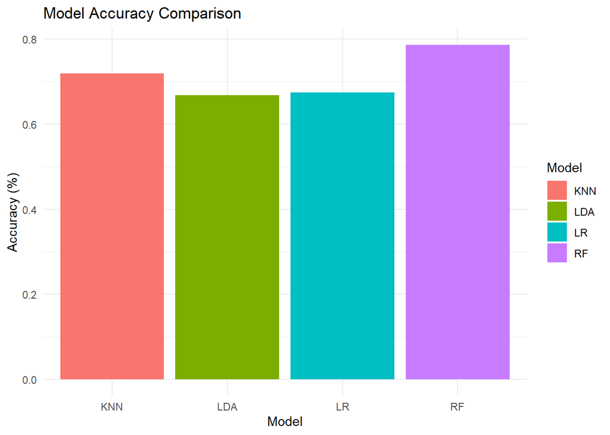

```r
# Plot accuracy for each model
ggplot(models_data[models_data$Class == "Good", ], aes(x = Model, y = Accuracy, fill = Model)) +
  geom_bar(stat = "identity", position = position_dodge()) +
  labs(title = "Model Accuracy Comparison", y = "Accuracy (%)", x = "Model") +
  theme_minimal()
```

[figure not shown]

[output not shown]

```r
# Plot precision, recall, and F1 score for each model and class
ggplot(models_melted, aes(x = Model, y = value, fill = Class)) +
  geom_bar(stat = "identity", position = position_dodge(), width = 0.7) +
  facet_wrap(~ variable, scales = "free_y") +
  labs(title = "Comparison of Precision, Recall, and F1 Score across Models",
       y = "Metric Value (%)", x = "Model") +
  theme_minimal()
```

The graphs above clearly indicate our four models’ performance across multiple metrics and the detailed statistic is shown in the chart above.

From the Model Accuracy Comparison figure, Random Forest displayed the highest accuracy, making it the most reliable for overall classification tasks in the financial sector.

Random forest has high Precision and Recall. In our research question, precision is essential in ensuring that classifications of ‘good’ credit scores are accurate, which may minimize risk. Recall is also important because it ensures that most actual ‘good’ scorers can be correctly identified, which is crucial for identifying reliable borrowers. Additionally, Random Forest also shows the high F1-Score, maintaining a balance between precision and recall. It is critical for minimizing misclassifications in financial decision-making.

# 6 Conclusion

The development process and the final results of this project have demonstrated substantial success in utilizing machine learning models to predict credit scores. However, there are several potential shortcomings and issues that need to be addressed:

1.Model Reliability and Overfitting:

Issue: Our final Random Forests Model may overfit the training data, leading to less reliable performance on unseen data. This can lead to inaccuracies in predicting credit scores, which are critical for financial decisions.

Future Work: Utilize techniques such as cross-validation, regularization, and ensemble methods to reduce overfitting. Periodically retrain models with new data to ensure they remain relevant and accurate.

2.Bias and Fairness:

Issue: Our models might unintentionally favor or discriminate against certain groups because they learn from old data that could be biased. This can lead to unfair decisions in who gets a loan or what terms they receive.

Future Work: We plan to regularly check and update our data to ensure it fairly represents everyone. We’ll also use specific techniques to remove any biases, making sure our credit scoring is fair for all customers. In this way, we make our financial services more reliable and equal for everyone.

3.Changing Economic Conditions:

Issue: Financial behaviors and credit score patterns can change due to economic fluctuations such as recessions or booms. Static models might not quickly adapt to such changes, leading to outdated predictions.

Future Work: We plan to develop models that automatically update with new data. In addition, we may incorporate economic indicators to adjust predictions based on current economic conditions.

In conclusion, this project starts with an IDA which sets foundation of the model chosen section. And the report effectively utilized machine learning techniques to develop models that predict individual credit scores based on personal financial information. The Random Forest model is selected based on rigorous evaluation. This algorithm stands out for its performance across multiple metrics. However, the models may still require further improvements to address issues of the models like overfitting and data quality.